# R Notebook

# Basic- Tour of RStudio

## Goals

### Project

### Console

### Vectors

### Variables

### Source

### Files

### Packages

### Help

### Viewer

### History

### Intellisense

### Cheat Sheets

# Create a New Project

[figure not shown]

File > New Project …

[figure not shown]

Pick New Project

[figure not shown]

Give it a name

If you know GIT you can create a GIT Repository but everyone should check “Open in new Session.”"

# Project Created

You should see your project and the R Studio interface.

[figure not shown]

# Console

The console is like DOS in Windows and Terminal in Mac or an SSH Shell.

```r
print("Hello IT Summit")
```

```
## [1] "Hello IT Summit"
```

Let’s create a new file.

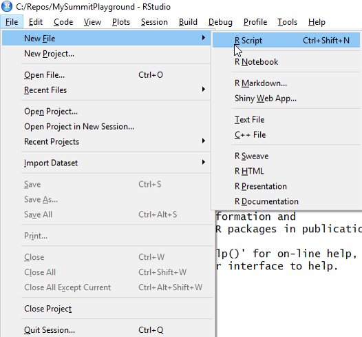

This is the source view. Type “print(”this is from a file“). Then click control (command for Mac) + Enter.

[figure not shown]

You can also highlight the line and click the Run button as seen below.

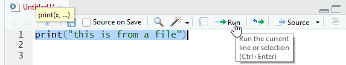

You can then rerun the same line by using (Control-Shift-P) or click the rerun button.

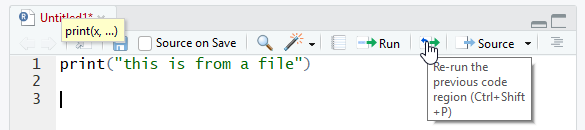

You can then change the line to read “There has been a change” and use (Control-Shift-P) and it will rerun the same line. This is a useful technique to use as you are tweaking code to get it exactly right.

```r
print("There has been a change")
```

```
## [1] "There has been a change"
```

Go ahead and save the file and look at the Files tab on the right.

[figure not shown]

[figure not shown]

# What is a package?

“Packages are collections of R functions, data, and compiled code in a well-defined format. The directory where packages are stored is called the library. ”-Quick R Web Page (https://www.statmethods.net/interface/packages.html)

- Excel -> R Function =same idea
- Data -> values in a defined format
- Compiled code-> just means R can run it

# There are many ways to load a package.

- You can use the Install on the package tab.
- You can use the library command.

```r
library(ggplot2)
```

You can also use “lib.loc” to specify the path to the R version you can currently using.

This can useful when you run packages on the University HPC.

# There are many ways to install a package.

You can click the install package icon in the Packages tab.

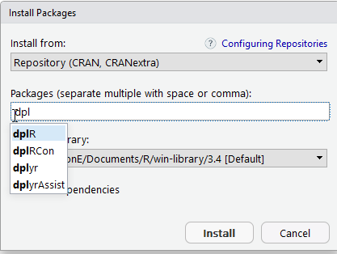

You can download a package from the web and install from a local zip file.

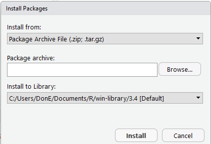

Someone hasn’t told R Studio that red is the color of an error.

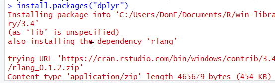

Look through the Packages tab and try installing some packages.